# Implementação do Plano Amostral da Pesquisa Nacional de Saúde no R: um estudo de caso sobre a asma no Brasil

I. Dube; M. E. L. Silva

29/07/2026

Relatório metodológico

Implementação do Plano Amostral da Pesquisa Nacional de Saúde no R: um estudo de caso sobre a asma no Brasil

Relatório técnico dos estimadores, intervalos de confiança, indicadores epidemiológicos e interpretação dos resultados da PNS 2013-2019 no contexto da asma.

I. Dube; M. E. L. Silva · 29/07/2026 · [Repositório do projeto](https://github.com/ingodube/PNS_2013_2019)

Pesquisa Nacional de Saúde Plano amostral Asma

# 1 Introdução

Indicadores epidemiológicos são medidas sintéticas que permitem descrever a frequência, a distribuição e a evolução de eventos relacionados à saúde em populações definidas. Prevalências, taxas, médias, proporções de uso de medicamentos e intervalos de confiança não são apenas resultados numéricos: eles organizam a leitura sobre necessidades de saúde, desigualdades territoriais, fatores de risco, acesso ao cuidado e desempenho de políticas públicas. Em pesquisas com dados observacionais, esses indicadores são particularmente relevantes, haja vista que permitem transformar respostas individuais em evidências úteis para vigilância epidemiológica, planejamento em saúde e priorização de intervenções.

A asma é um exemplo claro da necessidade de se fazer um gerenciamento responsável desses dados observacionais. Isso se deve por se tratar de uma condição respiratória crônica que combina diagnóstico médico, sintomas recorrentes, crises, manejo farmacológico, exposição a fatores de risco e possíveis limitações nas atividades cotidianas. Estimar a prevalência de diagnóstico médico de asma, a ocorrência de crises nos últimos 12 meses, o uso de medicamentos e a distribuição de fatores de risco como tabagismo contribui para avaliar se o aumento do diagnóstico vem acompanhado de melhor controle clínico e de acesso adequado ao tratamento.

Este trabalho apresenta a implementação do plano amostral da Pesquisa Nacional de Saúde (PNS) no R como estudo de caso sobre a asma no Brasil entre 2013 e 2019. O objetivo é demonstrar como microdados de inquéritos complexos podem ser convertidos em indicadores válidos, interpretáveis e reprodutíveis quando se respeitam pesos, estratos, unidades primárias de amostragem e procedimentos adequados de estimação da incerteza. Não obstante, também propõe-se uma exposição de todas as limitações e desafios de se utilizar dados amostrais quando não se tem, ou não se pode obter, uma base de dados populacional. A contribuição metodológica central deste trabalho está em explicitar o caminho entre os microdados originais, a construção dos indicadores e a leitura epidemiológica dos resultados, permitindo maior transparência e reprodutibilidade do procedimento adotado.

**Objetivo do ponto de vista Estatístico**

Documentar de forma reprodutível como os microdados da PNS são transformados em indicadores ponderados sobre diagnóstico de asma, crises, uso de medicamentos, tabagismo e indicadores complementares.

# 2 Fonte dos dados e escopo analítico

Os códigos usam microdados da PNS 2013 e 2019 obtidos pelo pacote `PNSIBGE`, com `get_pns(..., design = FALSE, labels = TRUE, selected = TRUE, anthropometry = FALSE)`. A PNS foi desenhada como inquérito domiciliar de base populacional, com plano probabilístico, estratificação e seleção por conglomerados em múltiplos estágios, de modo a produzir estimativas válidas para Brasil, grandes regiões, Unidades da Federação e outros domínios [2]. A opção `selected = TRUE` indica que as análises se concentram no morador selecionado para o questionário individual, que é o nível adequado para as perguntas de diagnóstico de asma, crises, medicamentos, tabagismo, absenteísmo e renda individual.

# 3 Implementação do plano amostral complexo

O método implementado constrói o desenho amostral com `PNSIBGE::pns_design()`, após manter as variáveis necessárias ao peso do morador selecionado e remover conjuntos concorrentes de pesos domiciliares ou antropométricos. Esse cuidado operacional se conecta diretamente ao desenho descrito para a PNS 2013: a inferência não deve tratar os microdados como amostra aleatória simples, pois a variância depende dos estratos, das unidades primárias de amostragem e dos pesos calibrados [2]. A rotina utilizada foi:

```r
cria_design_pns = function(data_pns){
  data_design = data_pns %>%
    select(-any_of(c("V0028", "V00281", "V00282", "V00283",
                     "V0030", "V00301", "V00302", "V00303")))

  pns_design(data_pns = data_design)
}
```

As variáveis centrais do desenho incluem `UPA_PNS`, `ID_DOMICILIO`, `V0024`, `V0029`, `V00291`, `V00292` e `V00293`. Em termos substantivos, elas representam a estrutura de conglomerados, estratificação e ponderação necessária para que cada respondente represente adequadamente a população-alvo. Ignorar essa estrutura tende a subestimar a incerteza e pode produzir conclusões excessivamente otimistas sobre diferenças entre anos ou Unidades da Federação.

Os códigos também definem:

```r
options(survey.lonely.psu = "adjust")
options(survey.adjust.domain.lonely = TRUE)
```

Essas opções evitam falhas em domínios estaduais ou subgrupos com unidades primárias de amostragem solitárias. A consequência prática é manter a estimação possível em recortes pequenos, com tratamento explícito da variância nesses domínios.

# 4 Estimadores e intervalos de confiança

**Estimador**

As estimativas priorizam proporções ponderadas, taxas por 100 mil habitantes e médias ponderadas, sempre preservando a estrutura de estratos, conglomerados e pesos da PNS.

Para variáveis binárias, a proporção ponderada é interpretada como:

$$\hat{p} = \frac{\sum_i w_i y_i}{\sum_i w_i}$$

em que $w_i$ é o peso amostral transformado do i-ésimo morador selecionado e $y_i$ é o indicador binário do evento para o i-ésimo indivíduo. A estimativa percentual é:

$$\hat{p_{\%}} = 100 \times \hat{p}$$

Da mesma forma, para taxas populacionais por 100 mil habitantes, o método estima a proporção no desenho complexo e depois reescala:

$$\hat{{p}_{100k}} = 100000 \times \hat{p}$$

Os intervalos de confiança de proporções usam:

```r
survey::svyciprop(formula_var, design = design_atual,
                  method = "beta", na.rm = TRUE)
```

Assim, o $IC_{95\%}$ é obtido na escala original da proporção pelo método beta e depois convertido para porcentagem ou taxa por 100 mil quando necessário. Essa abordagem evita truncamentos manuais de limites e reduz o risco de intervalos fora da escala 0-1.

Do ponto de vista estatístico, o intervalo de Wald é uma aproximação normal em torno da estimativa pontual. Essa aproximação pode ser frágil quando a proporção é baixa ou alta, quando há domínios com poucos respondentes efetivos ou quando a estrutura de amostragem complexa amplia a variância. Brown, Cai e DasGupta demonstram que o intervalo de Wald para proporções binomiais pode apresentar comportamento errático de cobertura, inclusive em tamanhos amostrais que frequentemente seriam considerados suficientes por regras práticas usuais [12]. Nos indicadores deste trabalho, essas situações aparecem em recortes estaduais, cujos tamanhos amostrais são naturalmente menores, no subgrupo de pessoas com diagnóstico médico de asma e, de forma ainda mais marcada, no subgrupo de pessoas com crise recente.

O método beta usado por `survey::svyciprop(method = "beta")` segue a família de soluções recomendadas para proporções estimadas em desenhos amostrais complexos, especialmente quando o número esperado de eventos positivos é pequeno ou quando a proporção se aproxima dos limites da escala [13]. Ele respeita a natureza limitada da proporção, produz limites compatíveis com a escala probabilística e evita a solução inadequada de simplesmente cortar valores negativos ou superiores a 100%.

**Atenção estatística**

A leitura visual das barras deve sempre ser combinada com os intervalos de confiança. Diferenças aparentes entre UFs ou anos não devem ser interpretadas como mudança clara quando a incerteza permanece amplamente sobreposta. Ou seja, se existe sobreposição dos intervalos de confiança, tecnicamente não existem evidências suficientes para afirmar que houve variação significativa de um ano para o outro.

Do ponto de vista aplicado, o uso do IC beta torna a leitura de política pública mais prudente. A comparação entre os anos de 2013 e 2019 deve considerar simultaneamente a magnitude da diferença e a incerteza ao redor das estimativas. Para estimar médias, como renda deflacionada e dias perdidos, os códigos usam `survey::svymean()`:

$$\bar{x} = \frac{\sum_i w_i x_i}{\sum_i w_i}$$

em que $x_i$ é uma variável contínua do i-ésimo morador selecionado e $w_i$ é o peso já calibrado pelo plano amostral da PNS para o i-ésimo indivíduo.

# 5 Indicadores de asma e fatores associados

Conforme destacado na introdução, a asma é uma doença respiratória crônica de grande relevância para vigilância em saúde, com impacto sobre sintomas, crises, qualidade de vida e uso de serviços. O Global Asthma Report 2022 reforça que a mensuração populacional é necessária para orientar políticas de prevenção, diagnóstico, acesso a tratamento e controle de sintomas [1]. No Brasil, a PNS 2013 já havia estimado a prevalência de diagnóstico médico de asma em adultos e mostrado diferenças por sexo, idade, escolaridade, região e presença de plano de saúde [4]. Estudos complementares sobre tendência da asma autorreferida entre 2003 e 2013 também apontam crescimento do diagnóstico em adultos, sugerindo que os resultados de 2013-2019 devem ser interpretados como parte de uma trajetória mais longa de mudança na detecção, acesso e perfil epidemiológico [6]. Para comparação internacional, levantamentos globais em adultos mostram grande variação entre países e reforçam que tabagismo, tratamento e diagnóstico precisam ser analisados conjuntamente [7].

## 5.1 Prevalência de diagnóstico médico de asma

O arquivo R `Extração PNS - Asma.R` recodifica `Q074` como `asma = 1` para “Sim”, `asma = 0` para “Não” e `NA` nos demais casos. As estimativas são calculadas por UF e para o Brasil.

Figura 1: Prevalência (%) de diagnóstico médico de asma por Unidade da Federação e Brasil, PNS 2013 e 2019.

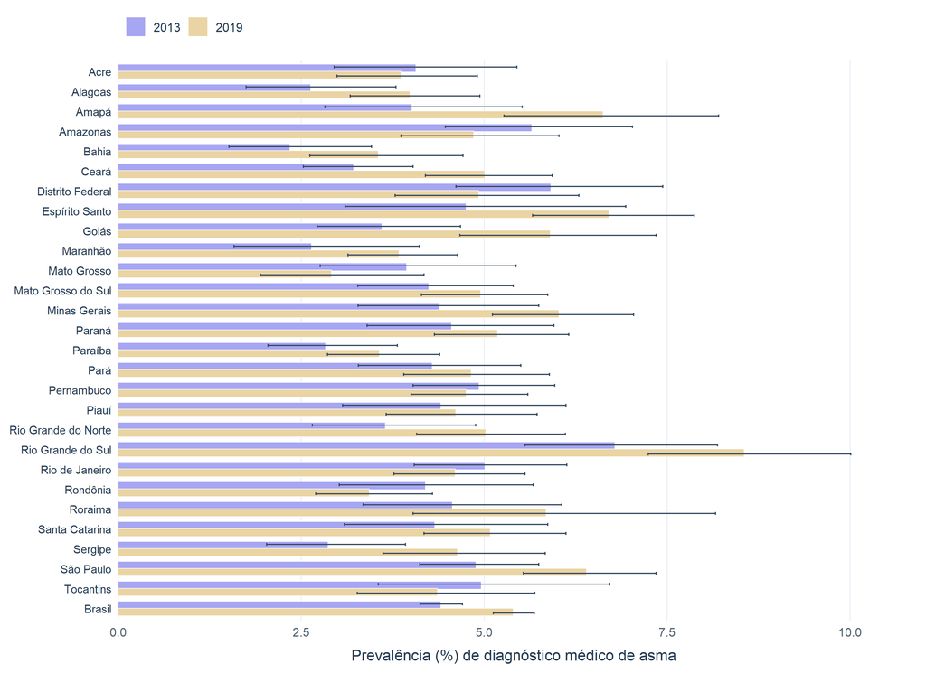

Fonte: elaborado pelos próprios autores.

Tabela 1: Prevalência de diagnóstico médico de asma por Unidade da Federação e Brasil, PNS 2013 e 2019.

| UF | 2013 | 2019 |
| --- | --- | --- |
| Acre | 4,07% [2,95%; 5,45%] | 3,87% [2,99%; 4,91%] |
| Alagoas | 2,63% [1,75%; 3,79%] | 3,99% [3,17%; 4,94%] |
| Amapá | 4,02% [2,82%; 5,52%] | 6,63% [5,27%; 8,21%] |
| Amazonas | 5,65% [4,47%; 7,03%] | 4,86% [3,86%; 6,02%] |
| Bahia | 2,35% [1,51%; 3,46%] | 3,56% [2,62%; 4,71%] |
| Ceará | 3,22% [2,53%; 4,03%] | 5,01% [4,20%; 5,93%] |
| Distrito Federal | 5,91% [4,62%; 7,44%] | 4,93% [3,78%; 6,30%] |
| Espírito Santo | 4,76% [3,10%; 6,94%] | 6,71% [5,66%; 7,87%] |
| Goiás | 3,61% [2,72%; 4,68%] | 5,91% [4,67%; 7,35%] |
| Maranhão | 2,64% [1,59%; 4,12%] | 3,84% [3,14%; 4,64%] |
| Mato Grosso | 3,94% [2,76%; 5,44%] | 2,91% [1,95%; 4,18%] |
| Mato Grosso do Sul | 4,24% [3,28%; 5,40%] | 4,96% [4,15%; 5,87%] |
| Minas Gerais | 4,39% [3,28%; 5,75%] | 6,03% [5,11%; 7,05%] |
| Paraná | 4,55% [3,40%; 5,96%] | 5,18% [4,32%; 6,16%] |
| Paraíba | 2,83% [2,05%; 3,82%] | 3,57% [2,86%; 4,39%] |
| Pará | 4,29% [3,28%; 5,50%] | 4,83% [3,90%; 5,89%] |
| Pernambuco | 4,93% [4,03%; 5,97%] | 4,75% [4,00%; 5,60%] |
| Piauí | 4,41% [3,07%; 6,12%] | 4,61% [3,66%; 5,72%] |
| Rio Grande do Norte | 3,65% [2,65%; 4,88%] | 5,02% [4,08%; 6,11%] |
| Rio Grande do Sul | 6,79% [5,56%; 8,19%] | 8,55% [7,24%; 10,01%] |
| Rio de Janeiro | 5,01% [4,04%; 6,13%] | 4,60% [3,77%; 5,56%] |
| Rondônia | 4,20% [3,02%; 5,67%] | 3,43% [2,70%; 4,30%] |
| Roraima | 4,57% [3,35%; 6,06%] | 5,85% [4,03%; 8,16%] |
| Santa Catarina | 4,33% [3,09%; 5,87%] | 5,08% [4,18%; 6,12%] |
| Sergipe | 2,87% [2,03%; 3,93%] | 4,64% [3,62%; 5,84%] |
| São Paulo | 4,89% [4,12%; 5,75%] | 6,40% [5,54%; 7,35%] |
| Tocantins | 4,96% [3,55%; 6,72%] | 4,36% [3,27%; 5,70%] |
| Brasil | 4,41% [4,13%; 4,71%] | 5,40% [5,13%; 5,69%] |

Fonte: elaborado pelos próprios autores.

No Brasil, a prevalência estimada de diagnóstico médico de asma passou de 4,41% em 2013 (IC 95%: 4,13 a 4,71) para 5,40% em 2019 (IC 95%: 5,13 a 5,69). Os ICs não se sobrepõem, reforçando a evidência de aumento no período.

Esse aumento pode refletir maior ocorrência da doença, melhora no diagnóstico médico ou ambos. A interpretação estadual deve considerar a amplitude e a sobreposição dos intervalos de confiança, especialmente em UFs com menor tamanho efetivo de amostra, o que leva a maiores ICs. Como o diagnóstico médico depende de acesso ao cuidado, diferenças estaduais podem refletir tanto carga epidemiológica quanto desigualdades de acesso a consulta, investigação clínica e registro do diagnóstico [4], [6].

## 5.2 Crises de asma nos últimos 12 meses

O arquivo R `Extração PNS - Crise Asma 12 Meses.R` usa `Q076` para construir `crise_asma_12m`. A estimativa representa a proporção que relatou crise no período de referência.

Figura 2: Prevalência (%) de crise de asma nos últimos 12 meses por Unidade da Federação e Brasil, PNS 2013 e 2019.

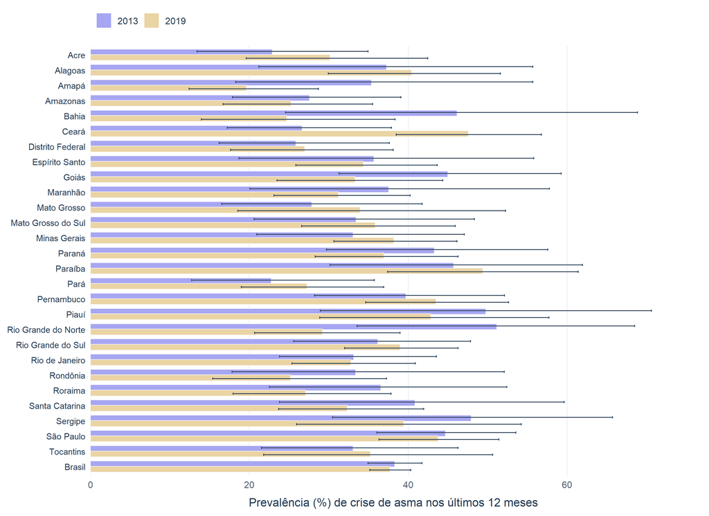

Fonte: elaborado pelos próprios autores.

Tabela 2: Crise de asma nos últimos 12 meses por Unidade da Federação e Brasil, PNS 2013 e 2019.

| UF | 2013 | 2019 |
| --- | --- | --- |
| Acre | 22,88% [13,40%; 34,93%] | 30,14% [19,61%; 42,47%] |
| Alagoas | 37,28% [21,22%; 55,69%] | 40,43% [29,93%; 51,61%] |
| Amapá | 35,37% [18,29%; 55,69%] | 19,63% [12,41%; 28,68%] |
| Amazonas | 27,56% [17,88%; 39,07%] | 25,26% [16,69%; 35,51%] |
| Bahia | 46,15% [24,56%; 68,86%] | 24,70% [13,96%; 38,36%] |
| Ceará | 26,63% [17,23%; 37,88%] | 47,57% [38,48%; 56,77%] |
| Distrito Federal | 25,86% [16,19%; 37,62%] | 26,97% [17,63%; 38,10%] |
| Espírito Santo | 35,67% [18,69%; 55,79%] | 34,35% [25,86%; 43,64%] |
| Goiás | 44,98% [31,30%; 59,25%] | 33,31% [23,47%; 44,35%] |
| Maranhão | 37,54% [20,06%; 57,78%] | 31,20% [23,10%; 40,25%] |
| Mato Grosso | 27,86% [16,52%; 41,75%] | 33,93% [18,56%; 52,26%] |
| Mato Grosso do Sul | 33,43% [20,60%; 48,33%] | 35,84% [26,60%; 45,92%] |
| Minas Gerais | 33,04% [20,92%; 47,06%] | 38,18% [30,65%; 46,15%] |
| Paraná | 43,26% [29,73%; 57,58%] | 36,94% [28,28%; 46,27%] |
| Paraíba | 45,72% [30,14%; 61,93%] | 49,37% [37,41%; 61,39%] |
| Pará | 22,75% [12,73%; 35,73%] | 27,27% [18,97%; 36,91%] |
| Pernambuco | 39,71% [28,20%; 52,12%] | 43,49% [34,65%; 52,64%] |
| Piauí | 49,75% [28,94%; 70,63%] | 42,85% [28,87%; 57,72%] |
| Rio Grande do Norte | 51,13% [33,55%; 68,51%] | 29,20% [20,65%; 38,98%] |
| Rio Grande do Sul | 36,17% [25,58%; 47,85%] | 38,97% [32,01%; 46,27%] |
| Rio de Janeiro | 33,14% [23,81%; 43,56%] | 32,79% [25,36%; 40,90%] |
| Rondônia | 33,37% [17,83%; 52,08%] | 25,19% [15,40%; 37,26%] |
| Roraima | 36,53% [22,54%; 52,41%] | 27,06% [17,95%; 37,84%] |
| Santa Catarina | 40,83% [23,81%; 59,63%] | 32,32% [23,68%; 41,96%] |
| Sergipe | 47,92% [30,49%; 65,72%] | 39,43% [25,93%; 54,22%] |
| São Paulo | 44,68% [36,06%; 53,54%] | 43,76% [36,31%; 51,41%] |
| Tocantins | 33,05% [21,53%; 46,27%] | 35,24% [21,81%; 50,62%] |
| Brasil | 38,29% [34,93%; 41,73%] | 37,71% [35,15%; 40,33%] |

Fonte: elaborado pelos próprios autores.

A ocorrência nacional de crises ficou em 38,29% em 2013 e 37,71% em 2019. A sobreposição dos IC 95% indica ausência de mudança estatisticamente clara.

A estabilidade das crises, mesmo diante do aumento da prevalência de diagnóstico, sugere que o controle clínico e o acesso continuado ao cuidado permanecem pontos críticos. Esse achado é coerente com a necessidade de integrar acesso farmacológico, seguimento clínico, educação em saúde e intervenções não farmacológicas, como redução de exposição a gatilhos ambientais e planejamento individual de manejo [1], [5].

## 5.3 Uso de medicamentos entre pessoas com asma

O arquivo R `Extração PNS - Medicamentos Asma.R` harmoniza perguntas distintas entre 2013 e 2019. Em 2013, `Q07701` identifica uso de medicamento. Em 2019, o uso é definido por medicamento oral (`Q07704`) ou bombinha (`Q07708`).

Figura 3: Uso de medicamento oral ou bombinha entre pessoas com diagnóstico médico de asma por Unidade da Federação e Brasil, PNS 2013 e 2019.

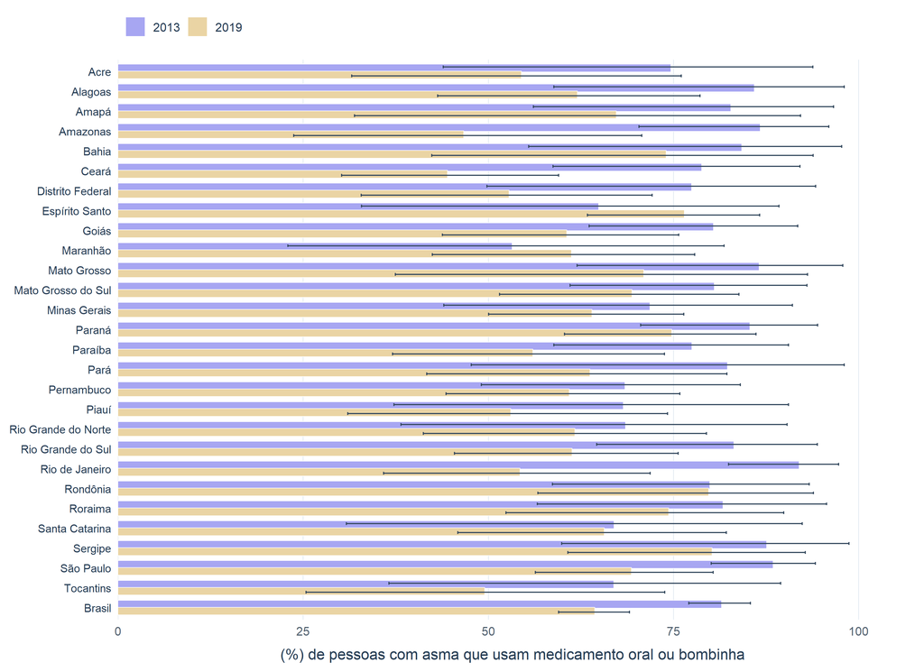

Fonte: elaborado pelos próprios autores.

Tabela 3: Uso de medicamento oral ou bombinha entre pessoas com diagnóstico médico de asma, PNS 2013 e 2019.

| UF | 2013 | 2019 |
| --- | --- | --- |
| Acre | 74,66% [43,93%; 93,83%] | 54,47% [31,58%; 76,05%] |
| Alagoas | 85,95% [58,87%; 98,07%] | 62,04% [43,17%; 78,58%] |
| Amapá | 82,76% [56,11%; 96,62%] | 67,30% [31,93%; 92,16%] |
| Amazonas | 86,72% [70,34%; 95,98%] | 46,70% [23,74%; 70,73%] |
| Bahia | 84,22% [55,45%; 97,71%] | 74,04% [42,37%; 93,86%] |
| Ceará | 78,81% [58,75%; 92,11%] | 44,49% [30,19%; 59,49%] |
| Distrito Federal | 77,45% [49,84%; 94,19%] | 52,79% [32,84%; 72,12%] |
| Espírito Santo | 64,90% [32,88%; 89,27%] | 76,46% [63,42%; 86,65%] |
| Goiás | 80,41% [63,61%; 91,80%] | 60,59% [43,81%; 75,73%] |
| Maranhão | 53,24% [22,96%; 81,84%] | 61,26% [42,46%; 77,89%] |
| Mato Grosso | 86,59% [61,99%; 97,89%] | 71,01% [37,48%; 93,10%] |
| Mato Grosso do Sul | 80,53% [61,07%; 93,02%] | 69,40% [51,51%; 83,83%] |
| Minas Gerais | 71,82% [43,99%; 91,07%] | 64,00% [50,05%; 76,42%] |
| Paraná | 85,31% [70,59%; 94,46%] | 74,79% [60,28%; 86,14%] |
| Paraíba | 77,50% [58,84%; 90,53%] | 56,03% [37,07%; 73,79%] |
| Pará | 82,30% [47,71%; 98,05%] | 63,73% [41,71%; 82,21%] |
| Pernambuco | 68,46% [49,08%; 84,06%] | 60,93% [44,32%; 75,86%] |
| Piauí | 68,25% [37,26%; 90,53%] | 53,03% [31,04%; 74,19%] |
| Rio Grande do Norte | 68,53% [38,21%; 90,35%] | 61,69% [41,26%; 79,48%] |
| Rio Grande do Sul | 83,19% [64,65%; 94,43%] | 61,33% [45,42%; 75,65%] |
| Rio de Janeiro | 91,98% [82,45%; 97,29%] | 54,29% [35,89%; 71,87%] |
| Rondônia | 79,94% [58,68%; 93,34%] | 79,76% [56,69%; 93,92%] |
| Roraima | 81,69% [56,61%; 95,67%] | 74,36% [52,38%; 89,91%] |
| Santa Catarina | 67,01% [30,86%; 92,39%] | 65,68% [45,89%; 82,15%] |
| Sergipe | 87,58% [59,92%; 98,72%] | 80,23% [60,76%; 92,82%] |
| São Paulo | 88,46% [80,12%; 94,17%] | 69,34% [56,38%; 80,39%] |
| Tocantins | 66,97% [36,61%; 89,49%] | 49,52% [25,39%; 73,81%] |
| Brasil | 81,50% [77,09%; 85,38%] | 64,40% [59,52%; 69,06%] |

Fonte: elaborado pelos próprios autores.

Entre pessoas com diagnóstico médico de asma, o uso de medicamento oral ou bombinha foi de 81,50% em 2013 e 64,40% em 2019. A ausência de sobreposição sugere mudança estatisticamente clara.

A queda percentual local pode ser influenciada por diferenças de mensuração entre questionários, por mudanças no perfil dos diagnosticados ou por alterações reais no acesso e na adesão ao tratamento.

## 5.4 Uso de medicamentos entre pessoas com crise recente

Este indicador restringe o denominador a pessoas com crise de asma nos últimos 12 meses e estima a proporção que usava medicamento.

Figura 4: Uso de medicamento oral ou bombinha entre pessoas com crise de asma nos últimos 12 meses por Unidade da Federação e Brasil, PNS 2013 e 2019.

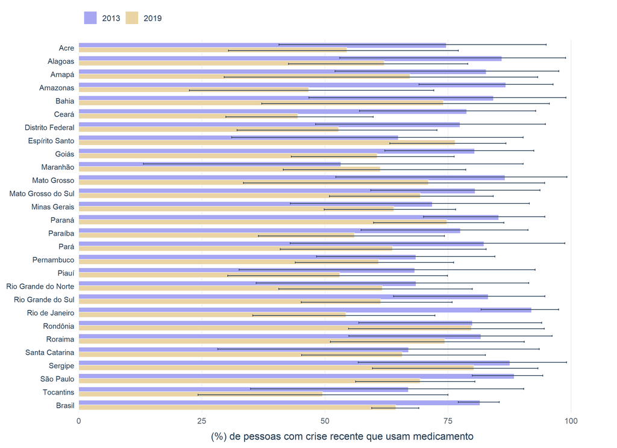

Fonte: elaborado pelos próprios autores.

Tabela 4: Uso de medicamento oral ou bombinha entre pessoas com crise de asma nos últimos 12 meses, PNS 2013 e 2019.

| UF | 2013 | 2019 |
| --- | --- | --- |
| Acre | 74,66% [40,69%; 94,95%] | 54,47% [30,42%; 77,08%] |
| Alagoas | 85,95% [53,01%; 98,88%] | 62,04% [42,60%; 79,01%] |
| Amapá | 82,76% [52,06%; 97,51%] | 67,30% [29,53%; 93,24%] |
| Amazonas | 86,72% [69,11%; 96,34%] | 46,70% [22,50%; 72,11%] |
| Bahia | 84,22% [46,76%; 98,95%] | 74,04% [37,18%; 95,59%] |
| Ceará | 78,81% [57,04%; 92,82%] | 44,49% [29,90%; 59,81%] |
| Distrito Federal | 77,45% [48,12%; 94,77%] | 52,79% [32,16%; 72,75%] |
| Espírito Santo | 64,90% [31,06%; 90,27%] | 76,46% [63,20%; 86,78%] |
| Goiás | 80,41% [62,18%; 92,43%] | 60,59% [43,17%; 76,24%] |
| Maranhão | 53,24% [13,14%; 90,29%] | 61,26% [41,54%; 78,60%] |
| Mato Grosso | 86,59% [52,22%; 99,17%] | 71,01% [33,44%; 94,64%] |
| Mato Grosso do Sul | 80,53% [59,33%; 93,70%] | 69,40% [50,94%; 84,20%] |
| Minas Gerais | 71,82% [42,98%; 91,53%] | 64,00% [49,84%; 76,58%] |
| Paraná | 85,31% [70,04%; 94,67%] | 74,79% [59,90%; 86,37%] |
| Paraíba | 77,50% [57,34%; 91,24%] | 56,03% [36,50%; 74,28%] |
| Pará | 82,30% [42,94%; 98,73%] | 63,73% [40,94%; 82,75%] |
| Pernambuco | 68,46% [48,32%; 84,54%] | 60,93% [43,97%; 76,15%] |
| Piauí | 68,25% [32,59%; 92,72%] | 53,03% [30,28%; 74,90%] |
| Rio Grande do Norte | 68,53% [36,02%; 91,41%] | 61,69% [40,63%; 79,95%] |
| Rio Grande do Sul | 83,19% [63,97%; 94,68%] | 61,33% [45,20%; 75,83%] |
| Rio de Janeiro | 91,98% [81,73%; 97,50%] | 54,29% [35,35%; 72,36%] |
| Rondônia | 79,94% [56,88%; 94,02%] | 79,76% [54,79%; 94,58%] |
| Roraima | 81,69% [54,87%; 96,15%] | 74,36% [51,13%; 90,51%] |
| Santa Catarina | 67,01% [28,27%; 93,54%] | 65,68% [45,25%; 82,59%] |
| Sergipe | 87,58% [56,79%; 99,07%] | 80,23% [59,68%; 93,26%] |
| São Paulo | 88,46% [79,92%; 94,26%] | 69,34% [56,24%; 80,49%] |
| Tocantins | 66,97% [34,92%; 90,38%] | 49,52% [24,23%; 74,99%] |
| Brasil | 81,50% [77,08%; 85,39%] | 64,40% [59,52%; 69,07%] |

Fonte: elaborado pelos próprios autores.

Esse recorte aproxima a análise do grupo com maior necessidade clínica recente. Diferenças estaduais devem ser interpretadas com cautela porque o subgrupo é menor e os intervalos de confiança tendem a ser mais largos.

## 5.5 Taxa populacional de uso de medicamentos para asma

O método implementado também estima a taxa por 100 mil habitantes para usuários de medicamentos orais ou bombinhas. Para esse indicador, `NA` em uso de medicamento é tratado como zero no numerador populacional, e a população-alvo recebe denominador unitário (`pop_taxa_medic_asma = 1`).

Figura 5: Taxa populacional de usuários de medicamento oral ou bombinha para tratamento de asma por 100 mil habitantes, PNS 2013 e 2019.

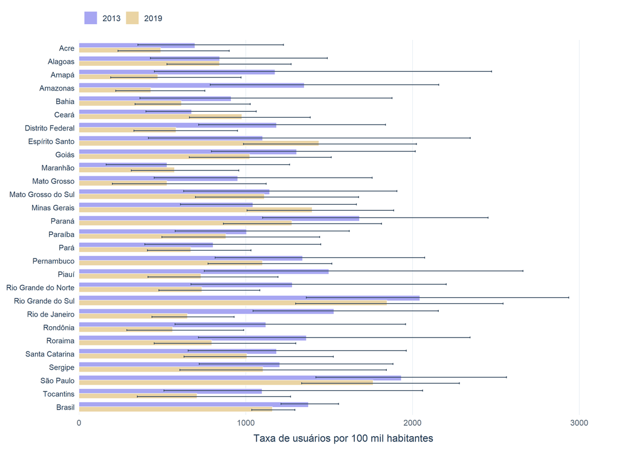

Fonte: elaborado pelos próprios autores.

Tabela 5: Taxa populacional de usuários de medicamento oral ou bombinha para asma por 100 mil habitantes, PNS 2013 e 2019.

| UF | 2013 | 2019 |
| --- | --- | --- |
| Acre | 695 [353; 1.226] | 490 [234; 901] |
| Alagoas | 843 [428; 1.489] | 842 [528; 1.272] |
| Amapá | 1.175 [452; 2.474] | 472 [190; 972] |
| Amazonas | 1.351 [787; 2.157] | 431 [221; 755] |
| Bahia | 912 [365; 1.877] | 614 [336; 1.027] |
| Ceará | 675 [402; 1.063] | 976 [662; 1.387] |
| Distrito Federal | 1.184 [717; 1.838] | 582 [330; 950] |
| Espírito Santo | 1.101 [416; 2.346] | 1.438 [986; 2.023] |
| Goiás | 1.305 [794; 2.017] | 1.024 [661; 1.513] |
| Maranhão | 528 [163; 1.263] | 572 [314; 958] |
| Mato Grosso | 951 [451; 1.758] | 527 [200; 1.122] |
| Mato Grosso do Sul | 1.143 [628; 1.906] | 1.111 [698; 1.677] |
| Minas Gerais | 1.043 [609; 1.663] | 1.398 [1.008; 1.887] |
| Paraná | 1.681 [1.101; 2.453] | 1.277 [866; 1.814] |
| Paraíba | 1.004 [577; 1.621] | 881 [497; 1.443] |
| Pará | 804 [395; 1.450] | 670 [411; 1.031] |
| Pernambuco | 1.341 [816; 2.073] | 1.100 [774; 1.516] |
| Piauí | 1.498 [751; 2.662] | 731 [414; 1.193] |
| Rio Grande do Norte | 1.279 [671; 2.202] | 737 [479; 1.084] |
| Rio Grande do Sul | 2.043 [1.363; 2.937] | 1.847 [1.299; 2.543] |
| Rio de Janeiro | 1.528 [1.044; 2.155] | 650 [437; 930] |
| Rondônia | 1.120 [576; 1.958] | 561 [287; 988] |
| Roraima | 1.363 [716; 2.345] | 796 [451; 1.300] |
| Santa Catarina | 1.184 [655; 1.963] | 1.007 [630; 1.525] |
| Sergipe | 1.203 [721; 1.883] | 1.103 [605; 1.843] |
| São Paulo | 1.932 [1.421; 2.563] | 1.763 [1.335; 2.281] |
| Tocantins | 1.098 [509; 2.060] | 707 [350; 1.269] |
| Brasil | 1.376 [1.211; 1.556] | 1.160 [1.036; 1.295] |

Fonte: elaborado pelos próprios autores.

A taxa populacional complementa a proporção entre asmáticos. Uma proporção menor entre diagnosticados pode coexistir com uma taxa populacional estável quando a prevalência de diagnóstico aumenta.

# 6 Tabagismo

O arquivo R `Extração PNS - Taxa de fumantes ativos.R` define fumante atual a partir de `P050`: fumantes diários ou menos que diários recebem `1`; não fumantes atuais recebem `0`; demais respostas permanecem como `NA`. A taxa por 100 mil usa o conjunto de respostas válidas como denominador.

Figura 6: Taxa de fumantes ativos por 100 mil habitantes por Unidade da Federação, PNS 2013 e 2019.

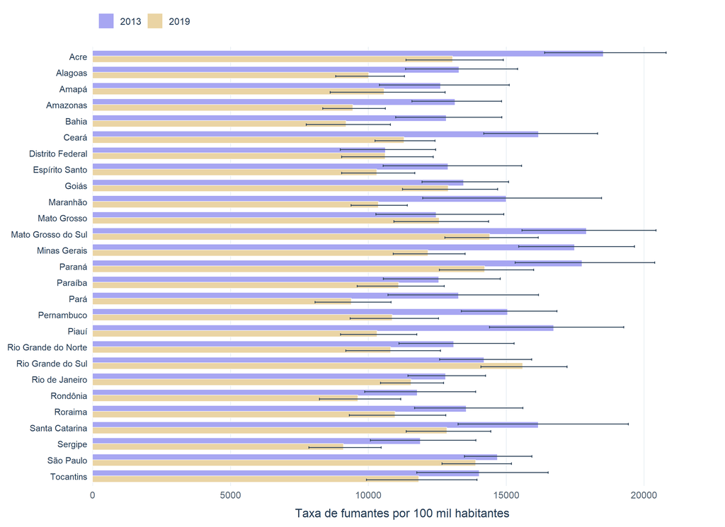

Fonte: elaborado pelos próprios autores.

| UF | 2013 | 2019 |
| --- | --- | --- |
| Acre | 18.528 [16.398; 20.808] | 13.062 [11.372; 14.901] |
| Alagoas | 13.287 [11.353; 15.416] | 10.016 [8.819; 11.315] |
| Amapá | 12.621 [10.407; 15.113] | 10.570 [8.619; 12.790] |
| Amazonas | 13.147 [11.585; 14.836] | 9.441 [8.353; 10.620] |
| Bahia | 12.827 [10.995; 14.841] | 9.193 [7.752; 10.802] |
| Ceará | 16.174 [14.188; 18.318] | 11.301 [10.250; 12.420] |
| Distrito Federal | 10.621 [8.985; 12.442] | 10.612 [9.037; 12.357] |
| Espírito Santo | 12.896 [10.542; 15.558] | 10.309 [9.039; 11.691] |
| Goiás | 13.461 [11.948; 15.089] | 12.897 [11.245; 14.696] |
| Maranhão | 15.003 [11.972; 18.460] | 10.367 [9.382; 11.418] |
| Mato Grosso | 12.461 [10.281; 14.914] | 12.573 [10.931; 14.364] |
| Mato Grosso do Sul | 17.913 [15.580; 20.438] | 14.410 [12.779; 16.164] |
| Minas Gerais | 17.484 [15.457; 19.659] | 12.166 [10.911; 13.510] |
| Paraná | 17.755 [15.333; 20.388] | 14.226 [12.578; 16.002] |
| Paraíba | 12.554 [10.548; 14.787] | 11.103 [9.599; 12.753] |
| Pará | 13.273 [10.720; 16.177] | 9.384 [8.074; 10.828] |
| Pernambuco | 15.051 [13.378; 16.845] | 10.868 [9.343; 12.546] |
| Piauí | 16.726 [14.395; 19.267] | 10.318 [8.994; 11.764] |
| Rio Grande do Norte | 13.099 [11.114; 15.293] | 10.815 [9.188; 12.620] |
| Rio Grande do Sul | 14.201 [12.593; 15.930] | 15.601 [14.084; 17.213] |
| Rio de Janeiro | 12.803 [11.445; 14.258] | 11.550 [10.445; 12.729] |
| Rondônia | 11.773 [9.873; 13.894] | 9.629 [8.230; 11.177] |
| Roraima | 13.556 [11.680; 15.610] | 10.973 [9.315; 12.812] |
| Santa Catarina | 16.168 [13.257; 19.431] | 12.856 [11.381; 14.447] |
| Sergipe | 11.891 [10.079; 13.901] | 9.096 [7.846; 10.472] |
| São Paulo | 14.684 [13.493; 15.938] | 13.898 [12.677; 15.191] |
| Tocantins | 14.020 [11.763; 16.527] | 11.830 [9.935; 13.942] |

Fonte: elaborado pelos próprios autores.

Nos outputs locais, a taxa de fumantes está disponível por UF. As maiores reduções absolutas entre 2013 e 2019 aparecem em: Piauí, Acre, Minas Gerais, Ceará, Maranhão. A leitura inferencial deve considerar os IC 95% de cada barra.

A redução do tabagismo é coerente com a narrativa de queda de fatores de risco respiratórios. Não obstante, o comportamento dos dados é diametralmente oposto à prevalência da doença. Sendo assim, o aumento do diangnóstico da doença pode se dar, sobretudo, pelo aumento de cerca de 41,30% de pneumologistas em atividade no Brasil, segundo dados do Conselho Federal de Medicina. Ou seja, quanto maior o número de profissionais especialistas neste tipo de doença, maior a probabilidade de diagnósticos dessa doença. Adicionalmente, a comparação estadual não deve se basear apenas na altura das barras: a sobreposição dos intervalos pode impedir conclusão estatística sobre mudança local.

# 7 Farmácia Popular e desembolso

O arquivo R `Extração PNS - Farmácia Popular.R` estima, para 2019, a proporção de usuários de medicamentos de asma que fizeram desembolso com medicamento oral (`Q07707`) ou bombinha (`Q07711`). O mesmo código também recodifica acesso via Farmácia Popular e serviço público, mas o output gráfico local planejado é `df_desembolso.xlsx`.

Figura 7: Proporção de usuários de medicamento oral ou bombinha para asma que fizeram desembolso, PNS 2019.

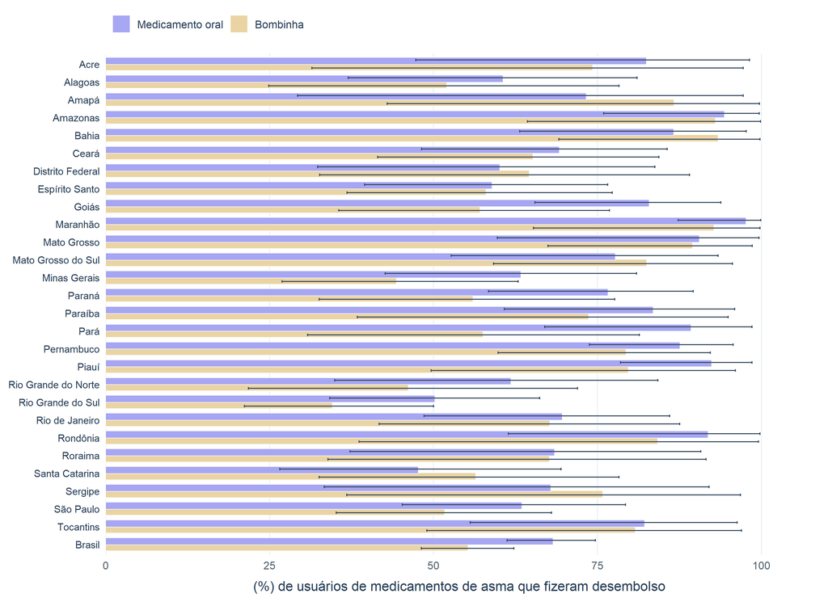

Fonte: elaborado pelos próprios autores.

Tabela 7: Proporção de usuários de medicamento oral ou bombinha para asma que fizeram desembolso, PNS 2019.

| UF | Medicamento | Estimativa [IC 95%] |
| --- | --- | --- |
| Acre | Bombinha | 74,28% [31,45%; 97,25%] |
| Alagoas | Bombinha | 52,02% [24,86%; 78,31%] |
| Amapá | Bombinha | 86,68% [42,93%; 99,74%] |
| Amazonas | Bombinha | 93,01% [64,33%; 99,88%] |
| Bahia | Bombinha | 93,44% [69,13%; 99,81%] |
| Ceará | Bombinha | 65,18% [41,51%; 84,38%] |
| Distrito Federal | Bombinha | 64,59% [32,66%; 89,05%] |
| Espírito Santo | Bombinha | 58,04% [36,80%; 77,29%] |
| Goiás | Bombinha | 57,11% [35,55%; 76,85%] |
| Maranhão | Bombinha | 92,79% [65,27%; 99,84%] |
| Mato Grosso | Bombinha | 89,53% [67,47%; 98,64%] |
| Mato Grosso do Sul | Bombinha | 82,52% [59,16%; 95,61%] |
| Minas Gerais | Bombinha | 44,37% [26,89%; 62,93%] |
| Paraná | Bombinha | 56,04% [32,57%; 77,67%] |
| Paraíba | Bombinha | 73,69% [38,40%; 94,96%] |
| Pará | Bombinha | 57,56% [30,80%; 81,40%] |
| Pernambuco | Bombinha | 79,36% [59,88%; 92,24%] |
| Piauí | Bombinha | 79,71% [49,63%; 96,08%] |
| Rio Grande do Norte | Bombinha | 46,15% [21,76%; 71,98%] |
| Rio Grande do Sul | Bombinha | 34,56% [21,16%; 50,02%] |
| Rio de Janeiro | Bombinha | 67,73% [41,72%; 87,55%] |
| Rondônia | Bombinha | 84,20% [38,66%; 99,57%] |
| Roraima | Bombinha | 67,70% [33,93%; 91,60%] |
| Santa Catarina | Bombinha | 56,45% [32,58%; 78,31%] |
| Sergipe | Bombinha | 75,82% [36,78%; 96,82%] |
| São Paulo | Bombinha | 51,73% [35,17%; 68,01%] |
| Tocantins | Bombinha | 80,79% [48,98%; 96,97%] |
| Brasil | Bombinha | 55,27% [48,13%; 62,26%] |
| Acre | Medicamento oral | 82,47% [47,29%; 98,20%] |
| Alagoas | Medicamento oral | 60,63% [37,02%; 81,07%] |
| Amapá | Medicamento oral | 73,28% [29,28%; 97,26%] |
| Amazonas | Medicamento oral | 94,38% [75,98%; 99,72%] |
| Bahia | Medicamento oral | 86,65% [63,15%; 97,70%] |
| Ceará | Medicamento oral | 69,21% [48,18%; 85,67%] |
| Distrito Federal | Medicamento oral | 60,12% [32,34%; 83,78%] |
| Espírito Santo | Medicamento oral | 58,96% [39,49%; 76,57%] |
| Goiás | Medicamento oral | 82,92% [65,47%; 93,85%] |
| Maranhão | Medicamento oral | 97,69% [87,33%; 99,95%] |
| Mato Grosso | Medicamento oral | 90,55% [59,75%; 99,67%] |
| Mato Grosso do Sul | Medicamento oral | 77,74% [52,72%; 93,42%] |
| Minas Gerais | Medicamento oral | 63,35% [42,65%; 80,97%] |
| Paraná | Medicamento oral | 76,62% [58,42%; 89,66%] |
| Paraíba | Medicamento oral | 83,51% [60,80%; 95,96%] |
| Pará | Medicamento oral | 89,29% [66,98%; 98,59%] |
| Pernambuco | Medicamento oral | 87,60% [73,79%; 95,72%] |
| Piauí | Medicamento oral | 92,44% [78,54%; 98,58%] |
| Rio Grande do Norte | Medicamento oral | 61,83% [34,95%; 84,24%] |
| Rio Grande do Sul | Medicamento oral | 50,21% [34,18%; 66,21%] |
| Rio de Janeiro | Medicamento oral | 69,67% [48,56%; 86,05%] |
| Rondônia | Medicamento oral | 91,90% [61,42%; 99,82%] |
| Roraima | Medicamento oral | 68,49% [37,28%; 90,77%] |
| Santa Catarina | Medicamento oral | 47,70% [26,57%; 69,46%] |
| Sergipe | Medicamento oral | 67,90% [33,33%; 92,07%] |
| São Paulo | Medicamento oral | 63,49% [45,24%; 79,29%] |
| Tocantins | Medicamento oral | 82,20% [55,63%; 96,34%] |
| Brasil | Medicamento oral | 68,25% [61,22%; 74,71%] |

Fonte: elaborado pelos próprios autores.

Esse indicador ajuda a distinguir acesso farmacológico de uso de medicamentos. Se parte relevante dos usuários paga diretamente pelo tratamento, políticas de provisão pública e assistência farmacêutica tornam-se centrais para o manejo da asma.

# 8 Absenteísmo, dias perdidos e renda

## 8.1 Absenteísmo por motivo de saúde

O arquivo R `Extração PNS - Dias Perdidos.R` recodifica `J002` como absenteísmo geral e transforma `J00402` em variáveis indicadoras para causas específicas em 2019. A estimativa geral usa o morador selecionado como denominador; já as causas específicas são estimadas entre moradores que deixaram de realizar atividades habituais por motivo de saúde. Cada proporção é estimada com `svyciprop(method = "beta")`.

Figura 8: Absenteísmo por motivo de saúde no Brasil, PNS 2019.

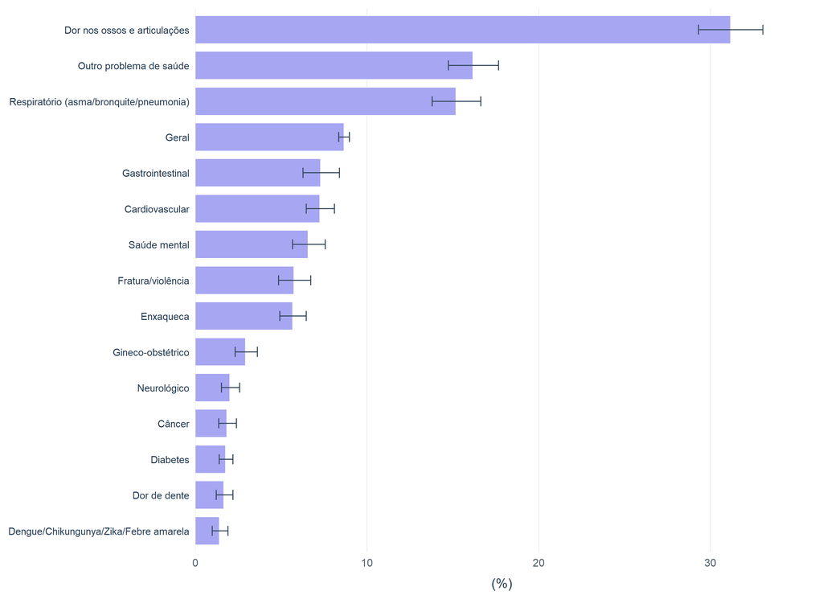

Fonte: elaborado pelos próprios autores.

Tabela 8: Absenteísmo por motivo de saúde no Brasil, PNS 2019.

| Indicador | Estimativa [IC 95%] |
| --- | --- |
| Dengue/Chikungunya/Zika/Febre amarela | 1,39% [0,99%; 1,91%] |
| Dor de dente | 1,65% [1,22%; 2,19%] |
| Diabetes | 1,76% [1,39%; 2,19%] |
| Câncer | 1,83% [1,37%; 2,40%] |
| Neurológico | 2,00% [1,52%; 2,59%] |
| Gineco-obstétrico | 2,92% [2,33%; 3,62%] |
| Enxaqueca | 5,66% [4,92%; 6,47%] |
| Fratura/violência | 5,73% [4,85%; 6,72%] |
| Saúde mental | 6,56% [5,66%; 7,56%] |
| Cardiovascular | 7,25% [6,46%; 8,11%] |
| Gastrointestinal | 7,29% [6,28%; 8,40%] |
| Geral | 8,66% [8,36%; 8,98%] |
| Respiratório (asma/bronquite/pneumonia) | 15,17% [13,80%; 16,63%] |
| Outro problema de saúde | 16,17% [14,74%; 17,67%] |
| Dor nos ossos e articulações | 31,17% [29,32%; 33,07%] |

Nota: Denominador: para o indicador geral, moradores selecionados com resposta válida sobre perda de atividades habituais; para motivos específicos, moradores que perderam atividades habituais por motivo de saúde. Método do IC: beta via

```
survey::svyciprop(method =
“beta”)
```

.

Fonte: elaborado pelos próprios autores.

O absenteísmo contextualiza a carga funcional de condições de saúde. A categoria respiratória agrega asma, bronquite e pneumonia, portanto não deve ser interpretada como estimativa isolada de asma. No gráfico, o valor geral responde à pergunta sobre ter deixado atividades habituais por motivo de saúde; os valores por causa descrevem a composição dos motivos entre os respondentes que tiveram perda de atividades.

## 8.2 Média de dias perdidos

Entre pessoas que relataram cada motivo, o método implementado estima a média ponderada de dias perdidos (`J003`) com `svymean()` e IC normal.

Figura 9: Média de dias perdidos por motivo de saúde no Brasil, PNS 2019.

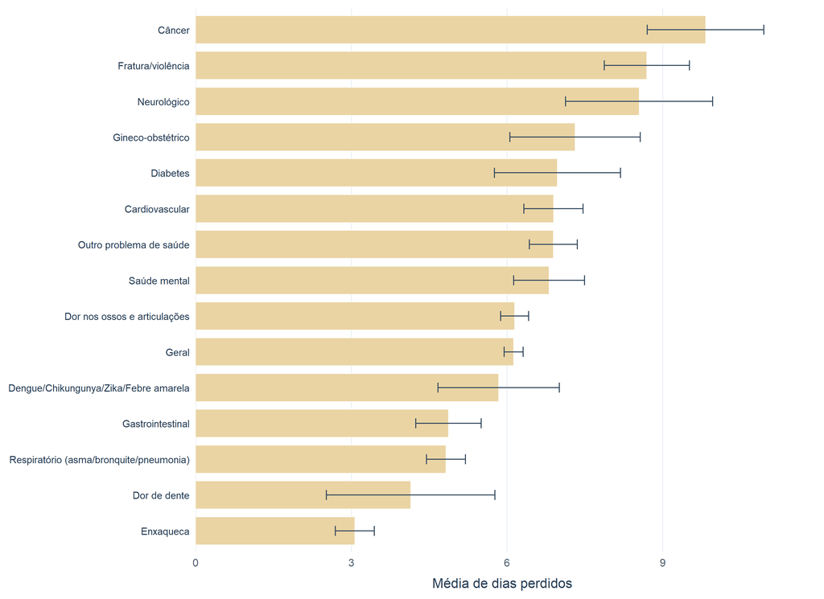

Fonte: elaborado pelos próprios autores.

Tabela 9: Média de dias perdidos por motivo de saúde no Brasil, PNS 2019.

| Motivo | Estimativa [IC 95%] |
| --- | --- |
| Enxaqueca | 3,1 [2,7; 3,4] |
| Dor de dente | 4,1 [2,5; 5,8] |
| Respiratório (asma/bronquite/pneumonia) | 4,8 [4,4; 5,2] |
| Gastrointestinal | 4,9 [4,2; 5,5] |
| Dengue/Chikungunya/Zika/Febre amarela | 5,8 [4,7; 7,0] |
| Geral | 6,1 [5,9; 6,3] |
| Dor nos ossos e articulações | 6,1 [5,9; 6,4] |
| Saúde mental | 6,8 [6,1; 7,5] |
| Outro problema de saúde | 6,9 [6,4; 7,4] |
| Cardiovascular | 6,9 [6,3; 7,5] |
| Diabetes | 7,0 [5,8; 8,2] |
| Gineco-obstétrico | 7,3 [6,1; 8,6] |
| Neurológico | 8,5 [7,1; 10,0] |
| Fratura/violência | 8,7 [7,9; 9,5] |
| Câncer | 9,8 [8,7; 10,9] |

Nota: Método do IC: aproximação normal via `survey::svymean()`.

Fonte: elaborado pelos próprios autores.

Esse resultado quantifica intensidade de impacto entre afetados. Como alguns motivos são raros, intervalos de confiança largos indicam maior incerteza.

## 8.3 Comparação respiratória harmonizada entre 2013 e 2019

A PNS 2013 e a PNS 2019 permitem comparar perda de atividades habituais e dias perdidos por motivo de saúde, mas as categorias do motivo principal não são idênticas. Por isso, este trabalho usa uma aproximação harmonizada e restrita a problemas respiratórios: em 2013, o domínio respiratório é formado pela soma conceitual das respostas `Asma / bronquite / pneumonia` e `Resfriado / gripe` em `J004`; em 2019, usa-se a categoria de `J00402` que reúne `Problemas respiratórios (resfriado/gripe/sinusite/asma/bronquite/pneumonia)`. A comparação, portanto, não estima asma isolada: ela estima um conjunto respiratório que contém asma e aproxima os dois questionários.

Tabela 10: Participação dos problemas respiratórios harmonizados entre moradores que perderam atividades habituais por motivo de saúde, Brasil, PNS 2013 e 2019.

| Ano | Estimativa [IC 95%] |
| --- | --- |
| 2013 | 15,44% [13,58%; 17,45%] |
| 2019 | 15,17% [13,80%; 16,63%] |

Nota: Indicador: participação dos problemas respiratórios harmonizados entre moradores que perderam atividades habituais por motivo de saúde. Denominador: moradores selecionados que perderam atividades habituais por motivo de saúde. Harmonização: em 2013, soma conceitual das categorias `Asma / bronquite / pneumonia` e

```
Resfriado /
gripe
```

; em 2019, categoria de problemas respiratórios que inclui resfriado, gripe, sinusite, asma, bronquite e pneumonia. Método do IC: beta via `survey::svyciprop(method = “beta”)`.

Fonte: elaborado pelos próprios autores.

Tabela 11: Média de dias perdidos por problemas respiratórios harmonizados, Brasil, PNS 2013 e 2019.

| Ano | Estimativa [IC 95%] |
| --- | --- |
| 2013 | 4,6 [4,1; 5,1] |
| 2019 | 4,8 [4,4; 5,2] |

Nota: Indicador: média de dias perdidos por problemas respiratórios harmonizados entre moradores que perderam atividades habituais por motivo de saúde. Denominador: moradores selecionados que perderam atividades habituais por motivo de saúde. Harmonização: em 2013, soma conceitual das categorias `Asma / bronquite / pneumonia` e `Resfriado / gripe`; em 2019, categoria de problemas respiratórios que inclui resfriado, gripe, sinusite, asma, bronquite e pneumonia. Método do IC: aproximação normal via `survey::svymean()`.

Fonte: elaborado pelos próprios autores.

No domínio respiratório harmonizado, a participação entre os motivos de perda de atividades foi de 15,44% em 2013 (IC 95%: 13,58 a 17,45) e 15,17% em 2019 (IC 95%: 13,80 a 16,63). A média de dias perdidos foi de 4,6 em 2013 e 4,8 em 2019. Como os intervalos são sobrepostos e a harmonização aproxima categorias não idênticas, a leitura deve privilegiar estabilidade aproximada da carga funcional respiratória, não mudança causal entre os anos.

## 8.4 Renda deflacionada

O arquivo R `Extração PNS - Renda.R` soma componentes de renda declarada, deflaciona os valores para agosto de 2025 pelo IPCA com `deflateBR` e estima renda média por UF e Brasil com `svymean()`.

Figura 10: Renda média deflacionada por Unidade da Federação e Brasil, PNS 2019.

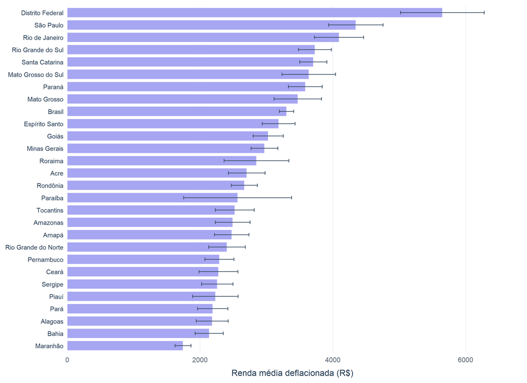

Nota: valores deflacionados a preços de agosto de 2025 pelo IPCA.

Fonte: elaborado pelos próprios autores.

Tabela 12: Renda média deflacionada por Unidade da Federação e Brasil, PNS 2019.

| UF | Estimativa [IC 95%] |
| --- | --- |
| Acre | 2.704 [2.428; 2.980] |
| Alagoas | 2.185 [1.945; 2.425] |
| Amapá | 2.478 [2.219; 2.737] |
| Amazonas | 2.492 [2.230; 2.754] |
| Bahia | 2.138 [1.926; 2.351] |
| Ceará | 2.278 [1.984; 2.573] |
| Distrito Federal | 5.652 [5.022; 6.283] |
| Espírito Santo | 3.186 [2.939; 3.433] |
| Goiás | 3.027 [2.800; 3.254] |
| Maranhão | 1.743 [1.623; 1.864] |
| Mato Grosso | 3.473 [3.116; 3.831] |
| Mato Grosso do Sul | 3.639 [3.235; 4.043] |
| Minas Gerais | 2.971 [2.769; 3.173] |
| Paraná | 3.587 [3.332; 3.842] |
| Paraíba | 2.567 [1.754; 3.380] |
| Pará | 2.192 [1.964; 2.420] |
| Pernambuco | 2.293 [2.073; 2.513] |
| Piauí | 2.231 [1.889; 2.573] |
| Rio Grande do Norte | 2.406 [2.131; 2.682] |
| Rio Grande do Sul | 3.732 [3.485; 3.979] |
| Rio de Janeiro | 4.094 [3.723; 4.465] |
| Rondônia | 2.668 [2.471; 2.866] |
| Roraima | 2.851 [2.363; 3.339] |
| Santa Catarina | 3.708 [3.503; 3.912] |
| Sergipe | 2.259 [2.022; 2.496] |
| São Paulo | 4.348 [3.938; 4.758] |
| Tocantins | 2.523 [2.229; 2.817] |
| Brasil | 3.303 [3.194; 3.412] |

Nota: Valores deflacionados a preços de agosto de 2025 pelo IPCA.

Fonte: elaborado pelos próprios autores.

A renda não é um desfecho de asma, mas contribui para interpretar desigualdades de acesso, diagnóstico, compra de medicamentos e capacidade de manejo da doença.

# 9 Interoperabilidade, OMOP e ETL em dados observacionais

O OMOP Common Data Model (CDM), mantido pela comunidade OHDSI, propõe padronizar estrutura e conteúdo de dados observacionais para permitir análises eficientes e evidência reprodutível em múltiplas bases [8], [9]. Em bases clínicas, um ETL para OMOP costuma mapear pacientes, visitas, condições, medicamentos, medidas e procedimentos para tabelas e vocabulários padronizados. No caso da PNS, a lógica é diferente: há respondentes de inquérito, variáveis autorreferidas, pesos amostrais, estratos e conglomerados. Portanto, um mapeamento literal para OMOP deve ser feito com cautela, porque o desenho amostral é parte constitutiva da informação e não pode ser descartado sem perda inferencial.

Mesmo com essa limitação, a discussão OMOP/OHDSI é útil para este trabalho. Primeiro, ela explicita a importância de documentar cada transformação, como `Q074` para diagnóstico de asma, `Q076` para crise recente e `P050` para tabagismo. Segundo, reforça a necessidade de vocabulários e conceitos harmonizados quando se deseja comparar inquéritos populacionais com bases assistenciais, como prontuários, dispensação farmacêutica ou sistemas administrativos. Terceiro, mostra que outputs reprodutíveis da PNS podem servir como camada populacional de referência para interpretar bases clínicas: por exemplo, prevalência populacional, distribuição estadual, carga de crises e padrões de uso de medicamentos.

Uma agenda futura viável é tratar a PNS como fonte complementar a uma rede de dados observacionais, como o sistema de informações hospitalares reportado pelo Sistema Único de Saúde (SUS). O ETL dos microdados geraria tabelas analíticas documentadas, enquanto bases clínicas em OMOP poderiam avaliar trajetórias de cuidado, prescrição, dispensação, exacerbações registradas e utilização de serviços. A interoperabilidade entre essas camadas ajudaria a distinguir três fenômenos que aparecem nos resultados: aumento do diagnóstico, estabilidade de crises e incerteza sobre acesso/uso de medicamentos. O valor principal está menos em forçar a PNS para dentro de um modelo clínico e mais em usar os princípios de padronização, documentação e reprodutibilidade do OMOP/OHDSI para tornar a evidência populacional comparável e auditável [8], [9], [10].

# 10 Síntese interpretativa

**Interpretação aplicada**

A síntese integra magnitude, direção temporal e incerteza estatística para evitar conclusões baseadas apenas na altura das barras ou em diferenças percentuais isoladas.

Tabela 13: Leitura integrada dos principais achados, PNS 2013 e 2019.

[output not shown]

Fonte: elaborado pelos próprios autores.

Em conjunto, os resultados indicam aumento do diagnóstico médico de asma entre 2013 e 2019, sem melhora clara nas crises recentes. A estabilidade das crises e a cautela na interpretação do uso de medicamentos sugerem que o manejo da asma depende não apenas de diagnóstico, mas também de acesso, adesão, acompanhamento clínico e intervenções não farmacológicas. A correta implementação do plano amostral complexo é essencial para que essas conclusões sejam comparáveis entre anos e entre Unidades da Federação.

# 11 Limitações operacionais da renderização

Este relatório não baixa microdados e não recalcula os objetos `survey` durante a renderização. Ele documenta a metodologia dos códigos e plota os outputs locais. Para regenerar todos os outputs desde os microdados, o ambiente R precisa ter, além dos pacotes usados neste Rmd, `PNSIBGE`, `survey`, `writexl`, `fastDummies` e `deflateBR`.

Caso `df_desembolso.xlsx` precise ser regenerado, execute o código de Farmácia Popular em ambiente com `PNSIBGE`, `survey` e `writexl` instalados:

```r
source(file.path("Códigos", "Extração PNS - Farmácia Popular.R"))
rmarkdown::render("docs/metodologia_pns.Rmd",
                  output_file = "metodologia.html",
                  output_dir = "docs",
                  clean = TRUE)
```

# 12 Referências

[1] GLOBAL ASTHMA NETWORK. *Global Asthma Report 2022*. Auckland, New Zealand: Global Asthma Network, 2022. Disponível em: https://globalasthmareport.org/resources/Global_Asthma_Report_2022.pdf. Acesso em: 19 set. 2025.

[2] SOUZA-JÚNIOR, Paulo Roberto Borges de et al. Desenho da amostra da Pesquisa Nacional de Saúde 2013. *Epidemiologia e Serviços de Saúde*, v. 24, p. 207-216, 2015.

[3] DUBE, I.; SILVA, M. E. L. *PNS_2013_2019*. GitHub, 2026. Disponível em: https://github.com/ingodube/PNS_2013_2019. Acesso em: 28 mai. 2026.

[4] MENEZES, A. M. B. et al. Prevalência de diagnóstico médico de asma em adultos brasileiros: Pesquisa Nacional de Saúde, 2013. *Revista Brasileira de Epidemiologia*, São Paulo, v. 18, supl. 2, p. 204-213, 2015.

[5] SEVERE ASTHMA. *Non-Pharmacological Interventions for Asthma*. Disponível em: https://www.severeasthma.org.au/non-pharmacological-interventions-asthma/. Acesso em: 19 set. 2025.

[6] SANTOS, Felipe Moraes dos et al. Tendência da prevalência de asma autorreferida no Brasil de 2003 a 2013 em adultos e fatores associados à prevalência. *Jornal Brasileiro de Pneumologia*, v. 44, n. 6, p. 491-497, 2018. doi:10.1590/S1806-37562017000000328.

[7] TO, T. et al. Global asthma prevalence in adults: findings from the cross-sectional world health survey. *BMC Public Health*, v. 12, art. 204, 2012. doi:10.1186/1471-2458-12-204.

[8] OHDSI. *Standardized Data: The OMOP Common Data Model*. Disponível em: https://www.ohdsi.org/data-standardization/.

[9] OHDSI. *OMOP Common Data Model*. Disponível em: https://ohdsi.github.io/CommonDataModel/.

[10] OHDSI. *ETL Creation Best Practices*. Disponível em: https://www.ohdsi.org/web/wiki/doku.php?id=documentation:etl_best_practices.

[11] LUMLEY, Thomas. *Complex Surveys: A Guide to Analysis Using R*. Hoboken: Wiley, 2010.

[12] BROWN, Lawrence D.; CAI, T. Tony; DASGUPTA, Anirban. Interval estimation for a binomial proportion. *Statistical Science*, v. 16, n. 2, p. 101-133, 2001. doi:10.1214/ss/1009213286.

[13] KORN, Edward L.; GRAUBARD, Barry I. Confidence intervals for proportions with small expected number of positive counts estimated from survey data. *Survey Methodology*, v. 24, n. 2, p. 193-201, 1998.

# 13 Declaração de uso de inteligência artificial

Durante a preparação deste trabalho, foi utilizado o ChatGPT/Codex, da OpenAI, com modelo GPT-5, como ferramenta de apoio à estruturação dos códigos, revisão de consistência, formatação do relatório, organização visual de tabelas e figuras e automação da renderização. O conteúdo científico, a seleção dos indicadores, a interpretação dos resultados, a validação das estimativas e a responsabilidade final pelo trabalho são dos autores. A ferramenta de inteligência artificial não foi utilizada como autora, não substituiu a análise crítica dos autores e não altera a responsabilidade humana sobre a integridade, a precisão e a apresentação das informações.